# BÁO CÁO CHI TIẾT ODICH_SXH_YEAR_2025

Author

Hoang Quoc Cuong

Published

April 23, 2026

# **ODICH_SXH 2025**

Báo cáo được cập nhập vào lúc **2026-04-23 16:47:01 | Dữ liệu ODICH_SXH 2025**

Bản đồ Cần Thơ (thông tin chi tiết phường, xã mới) [**click here**](https://tuhocr.github.io/canthosxh/MAP_CANTHO)

**Để copy file ảnh đồ thị full-size, ta right-click lên hình, chọn `Open image in new tab`**

# 1 **KIỂM TRA DỮ LIỆU**

**Nhập dữ liệu sai lệch năm (vd: file 2025 nhưng lại có bệnh nhân của năm 2026)**

**`Dữ liệu nhập lệch năm`**

```
Dữ liệu ban đầu: 2568
Dữ liệu sau khi lọc theo năm: 2547
Dữ liệu nhập lệch năm: 21
                   TTYTKV PHUONG_XA_MOI    NGAY_VV                HO    TEN TUOI NGUOI_NHAP_LIEU NGAY_NHAP_LIEU
100     TTYT KV Bình Thủy       An Bình 2026-01-02           Lê Nhật    Sơn   28     CDC Cần Thơ     2026-01-13
290     TTYT KV Bình Thủy     Bình Thủy 2026-01-03       Nguyễn Khắc   Hiển   50     CDC Cần Thơ     2026-01-13
342     TTYT KV Bình Thủy     Bình Thủy 2026-01-04          Võ Trung  Nghĩa   32     CDC Cần Thơ     2026-01-13
921      TTYT KV Long Phú      Long Phú 2026-01-05    Thái Thị Huỳnh    Như   17     CDC Cần Thơ     2026-01-13
1229     TTYT KV Cái Răng       Nhơn Ái 2026-01-04       La Thị Bích   Trâm   34     CDC Cần Thơ     2026-01-13
1305    TTYT KV Bình Thủy     Ninh Kiều 2026-01-03         Ngô Phước  Thiện   21     CDC Cần Thơ     2026-01-13
1340    TTYT KV Bình Thủy     Ninh Kiều 2026-01-03           Lê Ngọc   Thảo   54     CDC Cần Thơ     2026-01-13
1379    TTYT KV Bình Thủy     Ninh Kiều 2026-01-01      Nguyễn Phước  Thiện   13     CDC Cần Thơ     2026-01-13
1400    TTYT KV Bình Thủy     Ninh Kiều 2026-01-04        Đồng Thanh   Sang   29     CDC Cần Thơ     2026-01-13
1550 TTYT KV TP Sóc Trăng       Phú Lợi 2026-01-02       Nguyễn Xuân   Phúc    9     CDC Cần Thơ     2026-01-13
1583 TTYT KV TP Sóc Trăng       Phú Lợi 2026-01-01         Đặng Kiều   Tiên   13     CDC Cần Thơ     2026-01-13
1585 TTYT KV TP Sóc Trăng       Phú Lợi 2026-01-01           Dư Thái  Khang    6     CDC Cần Thơ     2026-01-13
1681 TTYT KV TP Sóc Trăng     Sóc Trăng 2026-01-02         Trần Minh Nguyệt   22     CDC Cần Thơ     2026-01-13
1730      TTYT KV Trần Đề       Tài Văn 2026-01-02   Trần Hoàng Phúc  Thịnh    1     CDC Cần Thơ     2026-01-13
1746    TTYT KV Bình Thủy        Tân An 2026-01-04          Bùi Quốc    Trí   15     CDC Cần Thơ     2026-01-13
1810    TTYT KV Bình Thủy        Tân An 2026-01-04       Nguyễn Ngọc  Quyên   24     CDC Cần Thơ     2026-01-13
1981     TTYT KV Thới Lai     Thạnh Phú 2026-01-02          Đặng Thị    Lắm   40     CDC Cần Thơ     2026-01-13
2006   TTYT KV Vĩnh Thạnh    Thạnh Quới 2026-01-02 Nguyễn Phạm Khánh    Thy   23     CDC Cần Thơ     2026-01-13
2042    TTYT KV Bình Thủy  Thới An Đông 2026-01-02          Đặng Đức   Điện   41     CDC Cần Thơ     2026-01-13
2191        TTYT KV Ô Môn     Thới Long 2026-01-02        Huỳnh Minh   Tùng   25     CDC Cần Thơ     2026-01-13
2265     TTYT KV Thốt Nốt    Thuận Hưng 2026-01-02  Nguyễn Trần Ngọc    Thy    6     CDC Cần Thơ     2026-01-13
```

**Nếu tổng số `TTYTKV` không vượt quá 22 (năm 2025) hay 20 (năm 2026) thì dữ liệu chính xác.**

**Tổng số TTYTKV là 22**

**`TTYTKV`**

```
    TTYT KV Bình Thủy      TTYT KV Cái Răng  TTYT KV Châu Thành A TTYT KV Châu Thành HG TTYT KV Châu Thành ST   TTYT KV Cù Lao Dung
                  833                   206                    13                    35                    77                    53
      TTYT KV Kế Sách       TTYT KV Long Mỹ      TTYT KV Long Phú         TTYT KV Mỹ Tú      TTYT KV Mỹ Xuyên       TTYT KV Ngã Năm
                  151                     2                   103                    33                    63                    89
        TTYT KV Ô Môn    TTYT KV Phụng Hiệp     TTYT KV Thạnh Trị      TTYT KV Thới Lai      TTYT KV Thốt Nốt  TTYT KV TP Sóc Trăng
                  134                    33                    25                   144                    66                   132
      TTYT KV Trần Đề       TTYT KV Vị Thủy     TTYT KV Vĩnh Châu    TTYT KV Vĩnh Thạnh
                  173                    38                   105                    39
Tổng số TTYTKV là 22
```

**Nếu tổng số `PHUONG_XA_MOI` không vượt quá 103 thì dữ liệu chính xác.**

**Tổng số PHUONG_XA_MOI là 98**

**`PHUONG_XA_MOI`**

```
        An Bình     An Lạc Thôn         An Ninh        An Thạnh       Bình Thủy         Cái Khế        Cái Răng      Châu Thành
            112              45              37              25             186              79              51              10
          Cờ Đỏ     Cù Lao Dung         Đại Hải        Đại Ngãi       Đại Thành       Đông Hiệp      Đông Phước      Đông Thuận
             20              28              11              14               8              10               3              14
        Gia Hòa       Hiệp Hưng     Hồ Đắc Kiện          Hòa An         Hỏa Lựu          Hòa Tú        Hưng Phú         Kế Sách
              5               2              10               2               3               8              54              47
      Khánh Hòa         Lai Hòa         Lâm Tân Lịch Hội Thượng         Liêu Tú       Long Hưng         Long Mỹ        Long Phú
             16               9               8              44              53               1               2              53
     Long Tuyền        Mỹ Hương        Mỹ Phước         Mỹ Quới           Mỹ Tú        Mỹ Xuyên         Ngã Bảy         Ngã Năm
             73              22               1              26               9              20               7              43
        Ngọc Tố         Nhơn Ái         Nhơn Mỹ         Nhu Gia       Ninh Kiều           Ô Môn      Phong Điền       Phong Nẫm
             27              47              19              23             114              51              35               6
        Phú Hữu         Phú Lộc         Phú Lợi         Phú Tâm      Phụng Hiệp      Phước Thới     Phương Bình       Sóc Trăng
             22              13              56              17               2              43               1              56
        Tài Văn          Tân An        Tân Bình         Tân Hòa         Tân Lộc        Tân Long  Tân Phước Hưng       Tân Thạnh
             23             173               2               7               8              20               1              15
       Thạnh An       Thạnh Hòa       Thạnh Phú      Thạnh Quới   Thạnh Thới An      Thạnh Xuân    Thới An Đông     Thới An Hội
              3               8              15              13              13               5              96              23
      Thới Hưng        Thới Lai       Thới Long        Thốt Nốt       Thuận Hòa      Thuận Hưng         Trần Đề      Trung Hưng
              5              23              40              25              13              23              40              16
     Trung Nhứt    Trường Khánh     Trường Long Trường Long Tây    Trường Thành     Trường Xuân          Vị Tân        Vị Thanh
             10              21              19               1              17              24              15              13
     Vị Thanh 1         Vị Thủy       Vĩnh Châu        Vĩnh Hải        Vĩnh Lợi      Vĩnh Phước      Vĩnh Thạnh Vĩnh Thuận Đông
              3               2              42              14               4              24              11               1
     Vĩnh Trinh      Vĩnh Tường
             12               1
Tổng số PHUONG_XA_MOI là 98
```

**Nếu kết quả tổng số ca theo `TTYTKV` và `PHUONG_XA_MOI` không vượt quá 103 thì dữ liệu chính xác.**

Số liệu này thể hiện bao nhiều phường xã có ca bệnh tương ứng với trung tâm y tế khu vực, tổng số không vượt qua 103 phường xã. Cần kiểm tra xem 1 phường xã có bị trùng ở các trung tâm y tế khu vực khác nhau không.

**Dữ liệu bị trùng**

```
        An Bình     An Lạc Thôn         An Ninh        An Thạnh       Bình Thủy         Cái Khế        Cái Răng      Châu Thành
              1               1               1               1               1               1               1               1
          Cờ Đỏ     Cù Lao Dung         Đại Hải        Đại Ngãi       Đại Thành       Đông Hiệp      Đông Phước      Đông Thuận
              1               1               1               1               1               1               1               1
        Gia Hòa       Hiệp Hưng     Hồ Đắc Kiện          Hòa An         Hỏa Lựu          Hòa Tú        Hưng Phú         Kế Sách
              1               1               1               1               1               1               1               1
      Khánh Hòa         Lai Hòa         Lâm Tân Lịch Hội Thượng         Liêu Tú       Long Hưng         Long Mỹ        Long Phú
              1               1               1               1               1               1               1               1
     Long Tuyền        Mỹ Hương        Mỹ Phước         Mỹ Quới           Mỹ Tú        Mỹ Xuyên         Ngã Bảy         Ngã Năm
              1               1               1               1               1               1               1               1
        Ngọc Tố         Nhơn Ái         Nhơn Mỹ         Nhu Gia       Ninh Kiều           Ô Môn      Phong Điền       Phong Nẫm
              1               1               1               1               1               1               1               1
        Phú Hữu         Phú Lộc         Phú Lợi         Phú Tâm      Phụng Hiệp      Phước Thới     Phương Bình       Sóc Trăng
              1               1               1               1               1               1               1               1
        Tài Văn          Tân An        Tân Bình         Tân Hòa         Tân Lộc        Tân Long  Tân Phước Hưng       Tân Thạnh
              1               1               1               1               1               1               1               1
       Thạnh An       Thạnh Hòa       Thạnh Phú      Thạnh Quới   Thạnh Thới An      Thạnh Xuân    Thới An Đông     Thới An Hội
              1               1               1               1               1               1               1               1
      Thới Hưng        Thới Lai       Thới Long        Thốt Nốt       Thuận Hòa      Thuận Hưng         Trần Đề      Trung Hưng
              1               1               1               1               1               1               1               1
     Trung Nhứt    Trường Khánh     Trường Long Trường Long Tây    Trường Thành     Trường Xuân          Vị Tân        Vị Thanh
              1               1               1               1               1               1               1               1
     Vị Thanh 1         Vị Thủy       Vĩnh Châu        Vĩnh Hải        Vĩnh Lợi      Vĩnh Phước      Vĩnh Thạnh Vĩnh Thuận Đông
              1               1               1               1               1               1               1               1
     Vĩnh Trinh      Vĩnh Tường
              1               1
Tổng số PHUONG_XA_MOI là 98
[1] TTYTKV        PHUONG_XA_MOI TONG_SO_CA
<0 rows> (or 0-length row.names)
```

# 2 **SỐ** **Ổ DỊCH** **THEO NGÀY [DỮ LIỆU GỐC]**

[**Dữ liệu gốc ODICH_SXH_2025**](https://tuhocr.github.io/canthosxh/REPORT/ODICH_SXH_2025)

# 3 **TỔNG SỐ** **Ổ DỊCH** **TRONG NĂM THEO KHU VỰC**

**Từ ngày 2025-01-01 đến ngày 2025-12-31**

**Tổng số ổ dịch: 2547 | Tổng số TTYT KV: 22 | Tổng số phường, xã: 103**

**Tổng số phường, xã có ổ dịch ODICH_SXH: 98**

**Tổng số phường, xã có KHÔNG có ODICH_SXH: 5 (Long Bình, Long Phú 1, Lương Tâm, Vĩnh Viễn, Xà Phiên)**

| TTYTKV | Phường, xã mới | Tổng số ca |
| --- | --- | --- |
| TTYT KV Bình Thủy | Bình Thủy | 186 |
| TTYT KV Bình Thủy | Tân An | 173 |
| TTYT KV Bình Thủy | Ninh Kiều | 114 |
| TTYT KV Bình Thủy | An Bình | 112 |
| TTYT KV Bình Thủy | Thới An Đông | 96 |
| TTYT KV Bình Thủy | Cái Khế | 79 |
| TTYT KV Bình Thủy | Long Tuyền | 73 |
| TTYT KV Châu Thành A | Tân Hòa | 7 |
| TTYT KV Châu Thành A | Thạnh Xuân | 5 |
| TTYT KV Châu Thành A | Trường Long Tây | 1 |

[output cut: 88 more lines]

# 4 **ĐỒ THỊ TỔNG SỐ** **Ổ DỊCH** **THEO KHU VỰC**

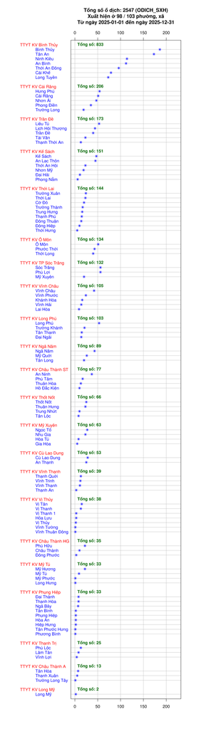

# 5 **TỔNG SỐ** **Ổ DỊCH** **THEO THÁNG**

| TTYTKV | Phường, xã mới | Tháng | Tổng số ca |
| --- | --- | --- | --- |
| TTYT KV Châu Thành ST | An Ninh | 1 | 2 |
| TTYT KV Bình Thủy | Bình Thủy | 1 | 2 |
| TTYT KV Bình Thủy | Cái Khế | 1 | 4 |
| TTYT KV Cái Răng | Cái Răng | 1 | 2 |
| TTYT KV Thới Lai | Cờ Đỏ | 1 | 1 |
| TTYT KV Long Phú | Đại Ngãi | 1 | 1 |
| TTYT KV Phụng Hiệp | Đại Thành | 1 | 1 |
| TTYT KV Thới Lai | Đông Thuận | 1 | 1 |
| TTYT KV Mỹ Xuyên | Hòa Tú | 1 | 1 |
| TTYT KV Trần Đề | Lịch Hội Thượng | 1 | 1 |

[output cut: 649 more lines]

# 6 **ĐỒ THỊ TỔNG SỐ** **Ổ DỊCH** **THEO THỜI GIAN**

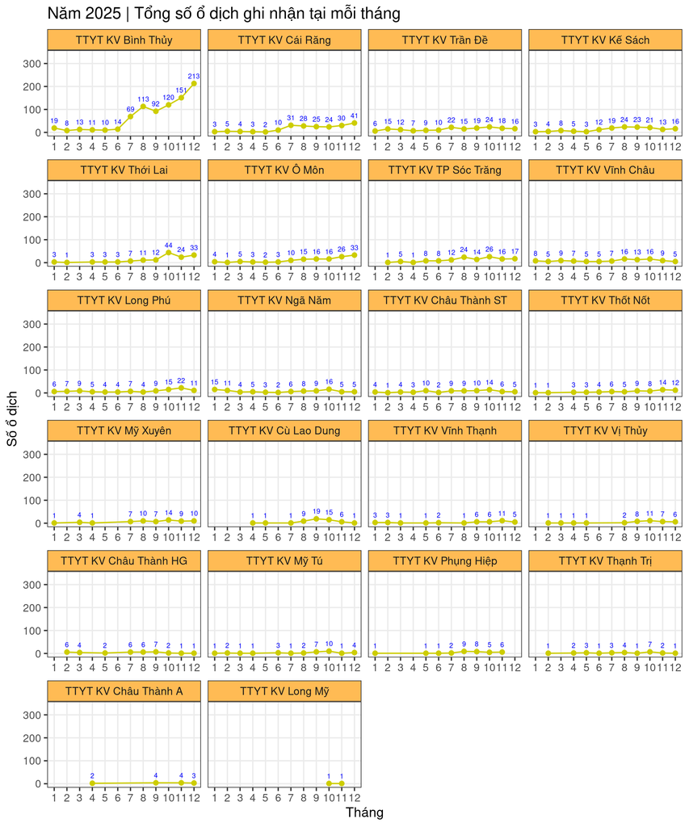

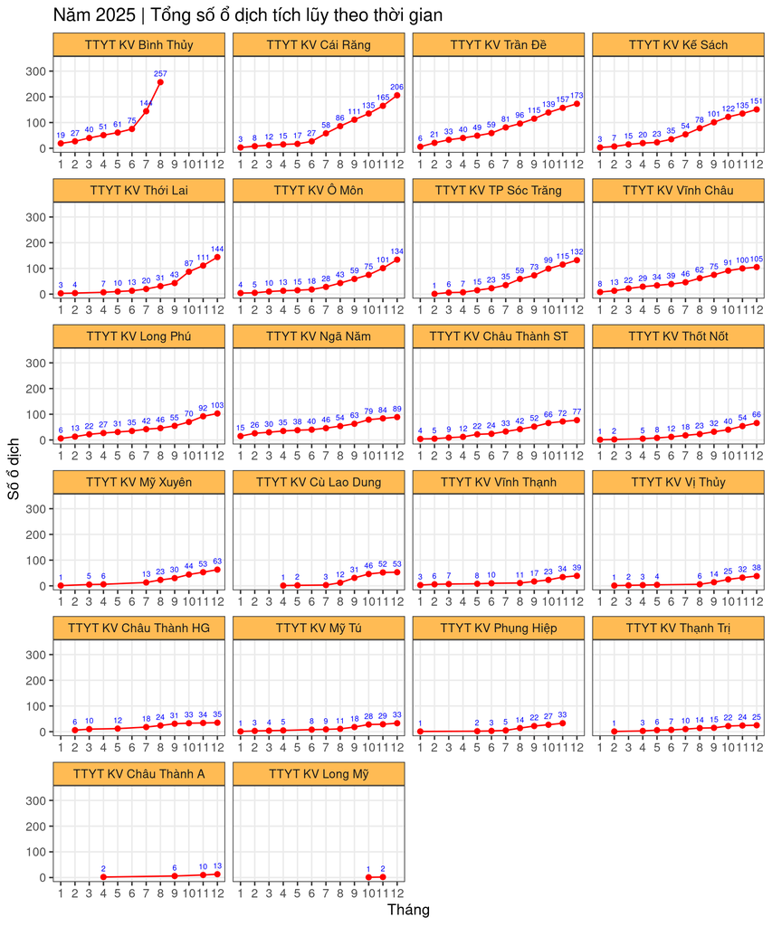

# 7 **TỔNG SỐ** **Ổ DỊCH** **THEO TUẦN**

| TTYTKV | PHUONG_XA_MOI | WEEK | COUNT |
| --- | --- | --- | --- |
| TTYT KV Bình Thủy | Cái Khế | 1 | 2 |
| TTYT KV Thới Lai | Cờ Đỏ | 1 | 1 |
| TTYT KV Long Phú | Đại Ngãi | 1 | 1 |
| TTYT KV Phụng Hiệp | Đại Thành | 1 | 1 |
| TTYT KV Thới Lai | Đông Thuận | 1 | 1 |
| TTYT KV Mỹ Xuyên | Hòa Tú | 1 | 1 |
| TTYT KV Trần Đề | Lịch Hội Thượng | 1 | 1 |
| TTYT KV Trần Đề | Liêu Tú | 1 | 1 |
| TTYT KV Mỹ Tú | Mỹ Hương | 1 | 1 |
| TTYT KV Ngã Năm | Mỹ Quới | 1 | 1 |

[output cut: 1353 more lines]

# 8 **ĐỒ THỊ THEO NGÀY**

## 8.1 TTYT KV Long Phú

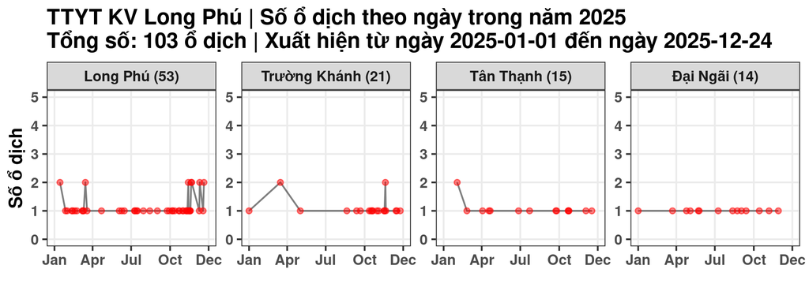

## 8.2 TTYT KV Thới Lai

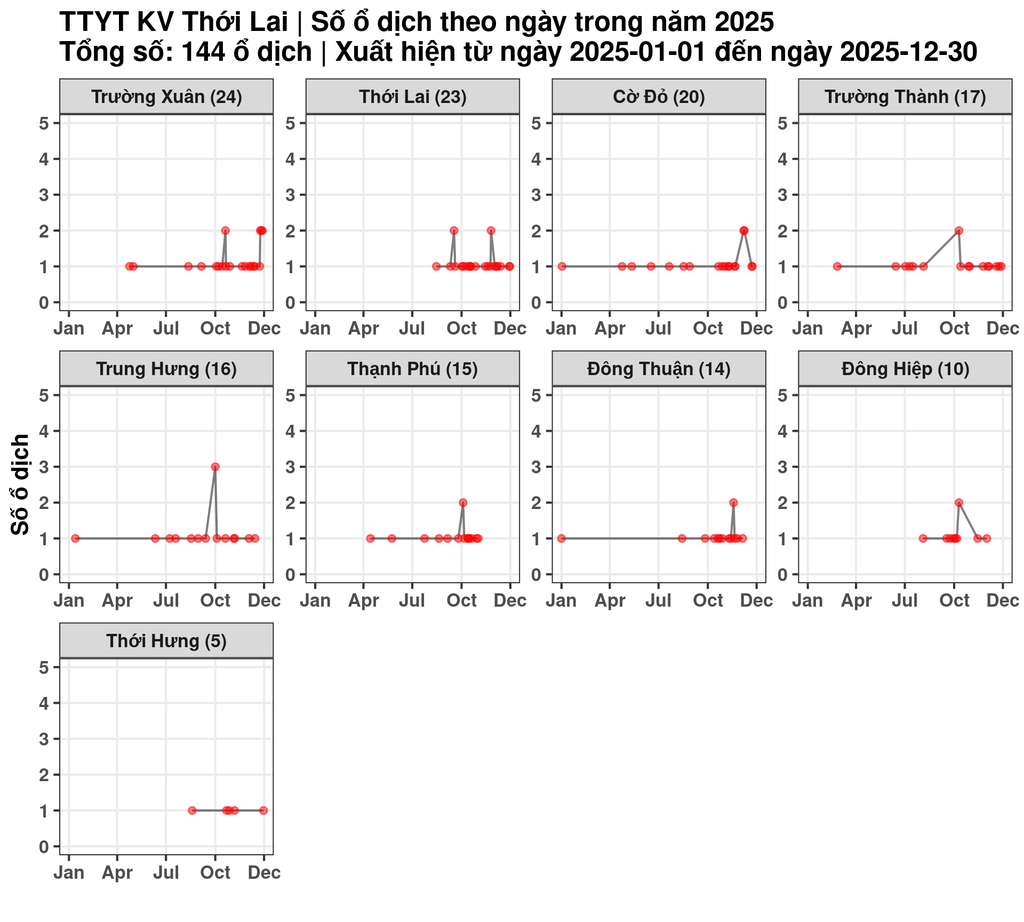

## 8.3 TTYT KV Ngã Năm

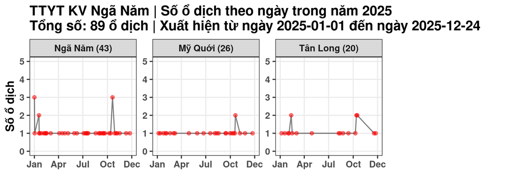

## 8.4 TTYT KV Ô Môn

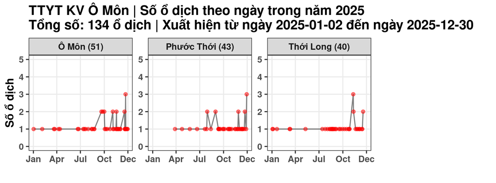

## 8.5 TTYT KV Bình Thủy

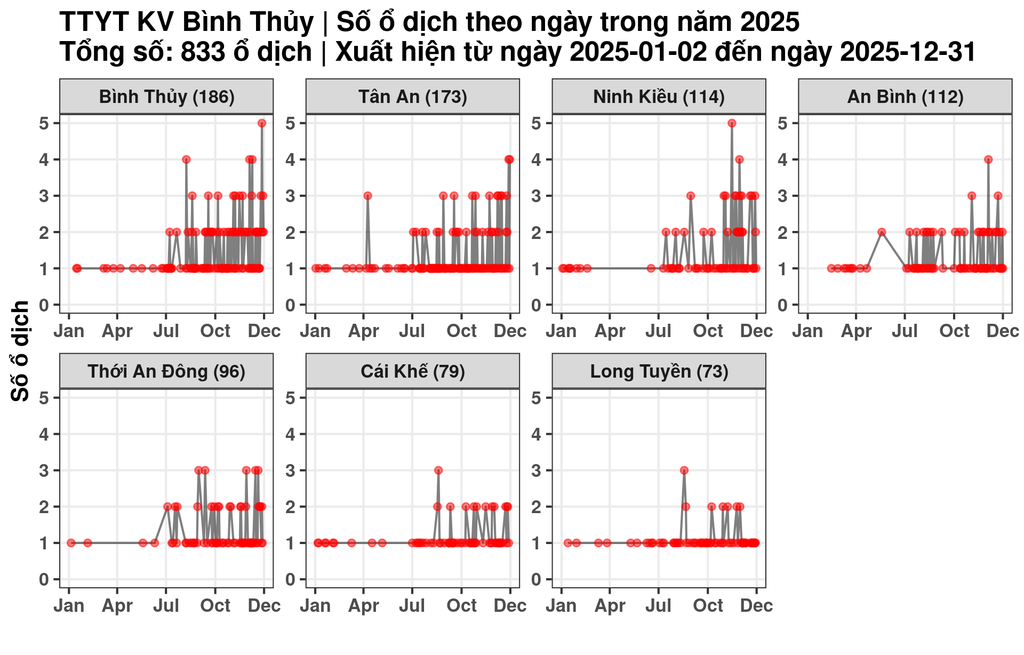

## 8.6 TTYT KV Trần Đề

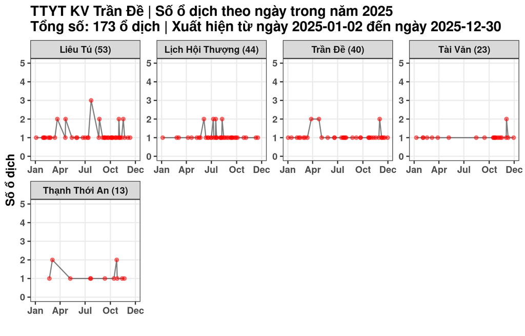

## 8.7 TTYT KV Thốt Nốt

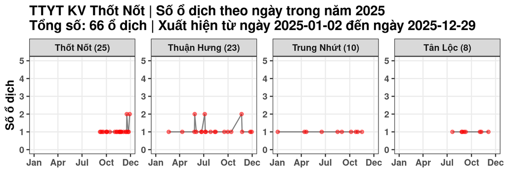

## 8.8 TTYT KV Mỹ Xuyên

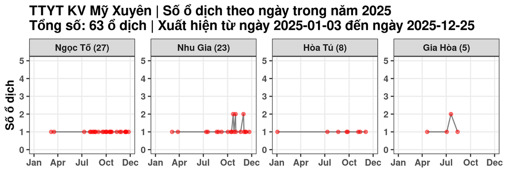

## 8.9 TTYT KV Vĩnh Châu

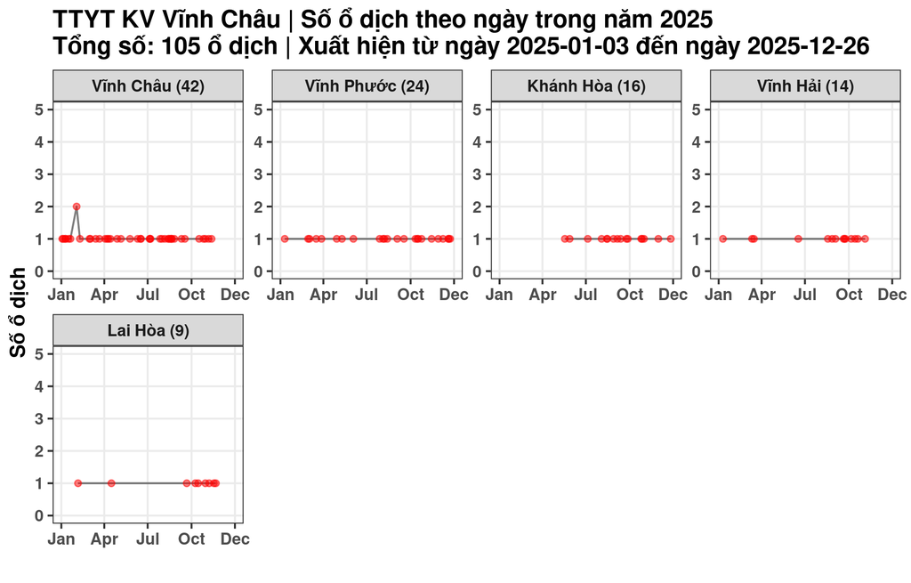

## 8.10 TTYT KV Vĩnh Thạnh

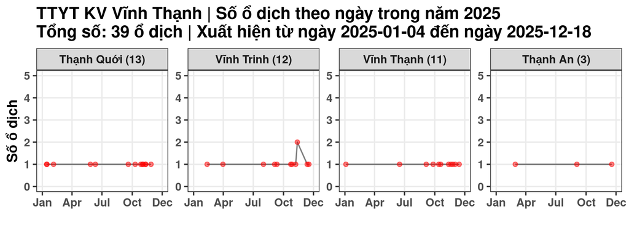

## 8.11 TTYT KV Phụng Hiệp

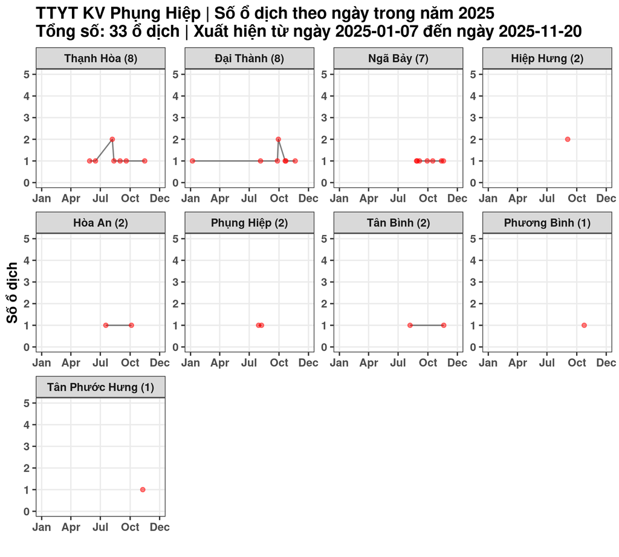

## 8.12 TTYT KV Mỹ Tú

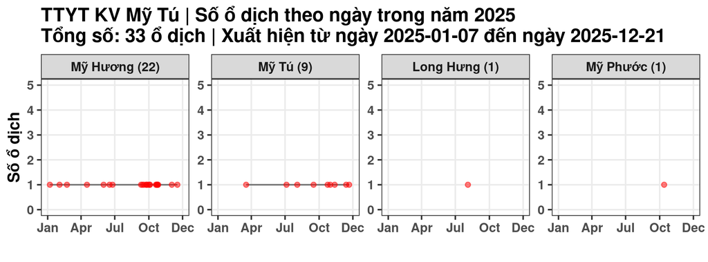

## 8.13 TTYT KV Châu Thành ST

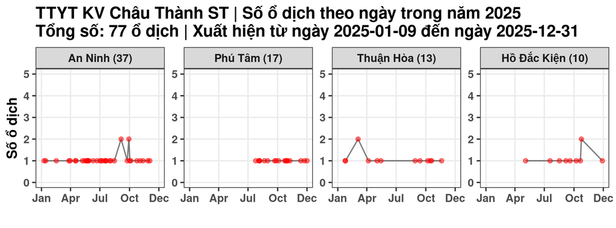

## 8.14 TTYT KV Cái Răng

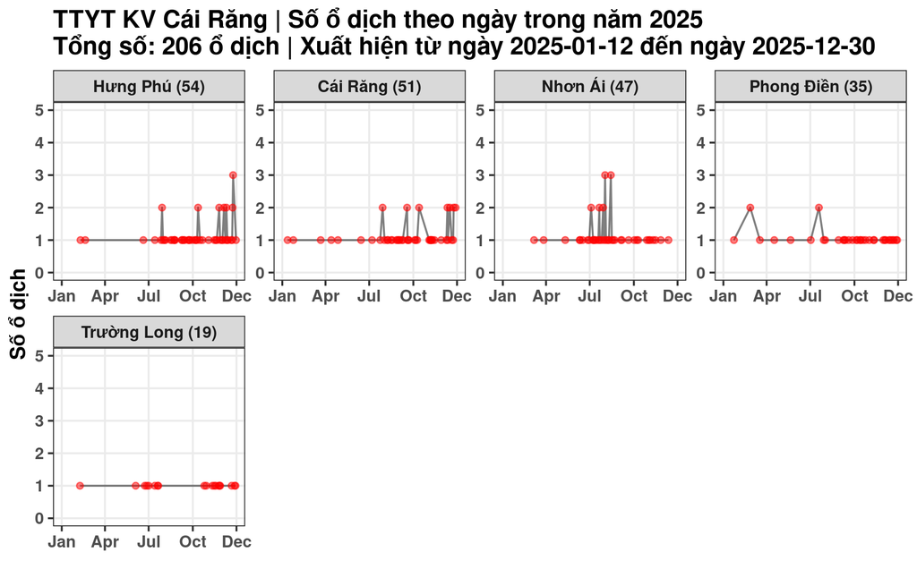

## 8.15 TTYT KV Kế Sách

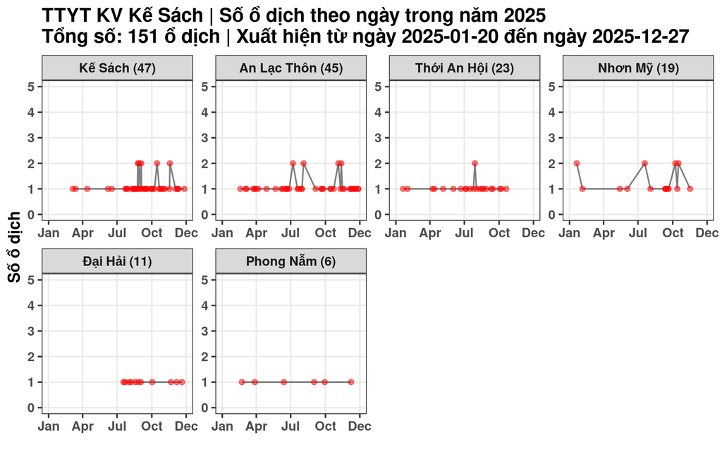

## 8.16 TTYT KV Vị Thủy

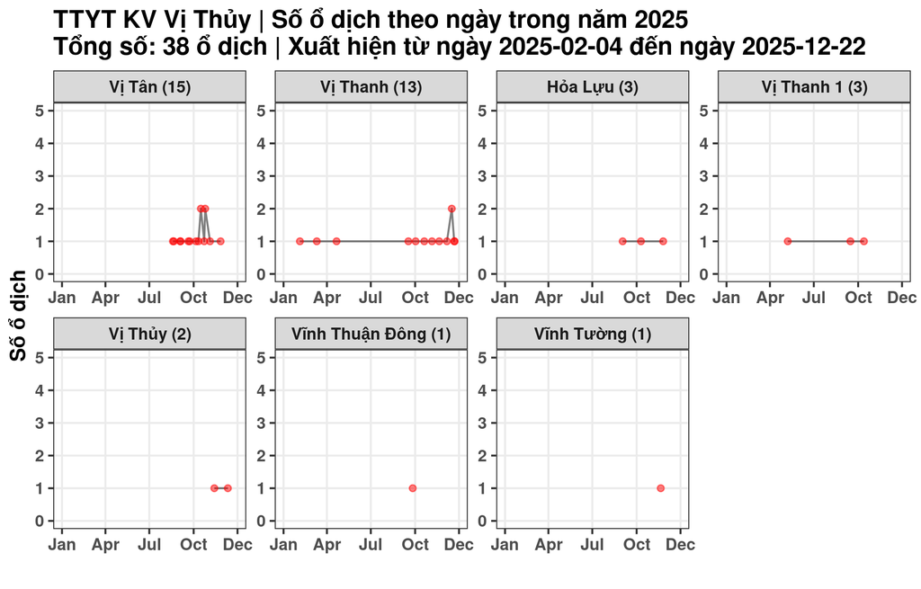

## 8.17 TTYT KV Châu Thành HG

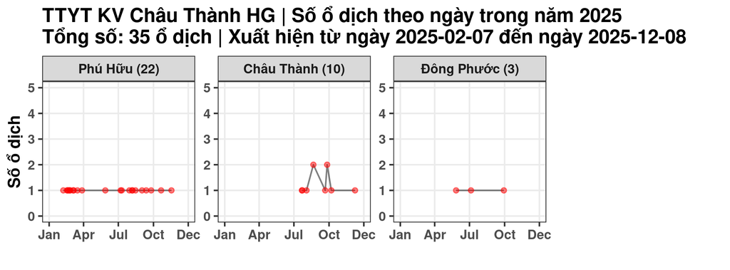

## 8.18 TTYT KV TP Sóc Trăng

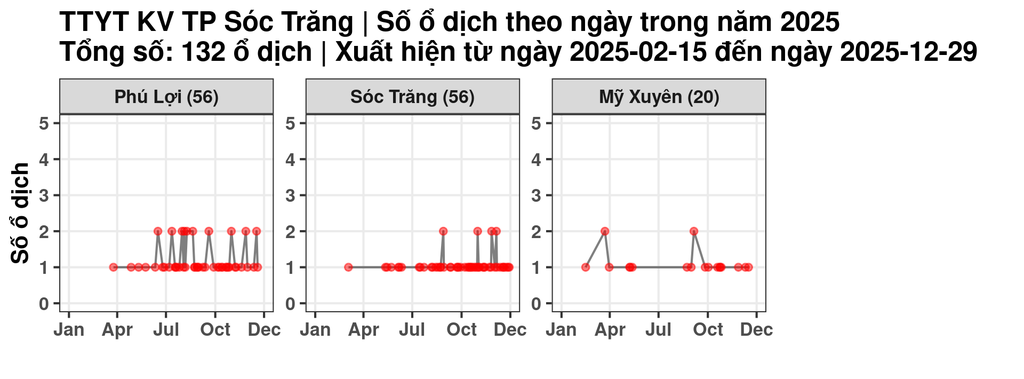

## 8.19 TTYT KV Thạnh Trị

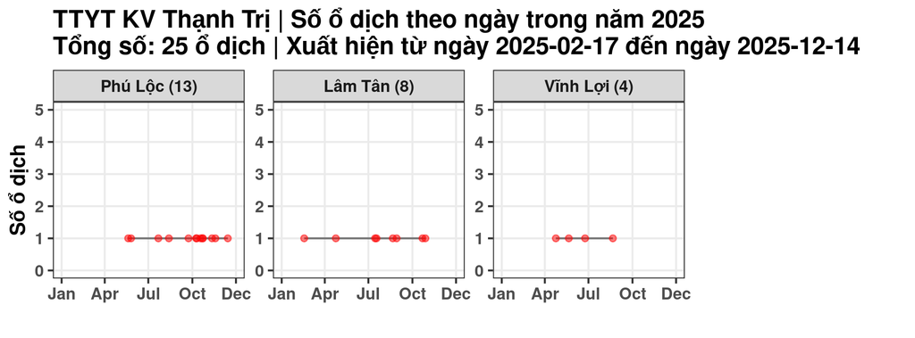

## 8.20 TTYT KV Cù Lao Dung

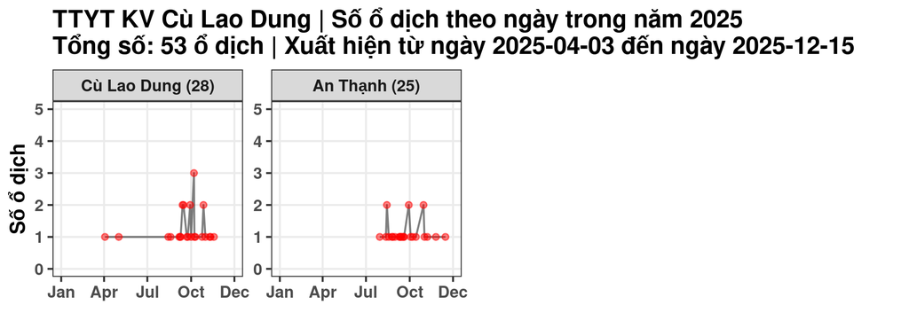

## 8.21 TTYT KV Châu Thành A

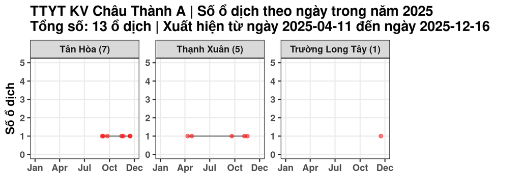

## 8.22 TTYT KV Long Mỹ

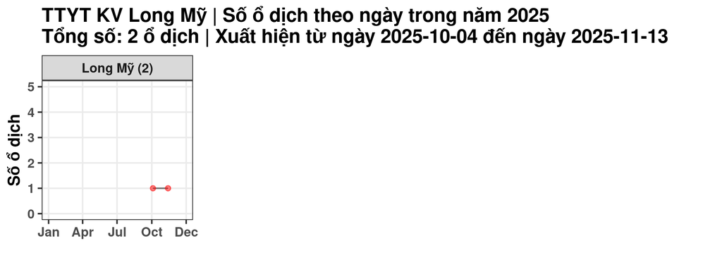

# 9 **ĐỒ THỊ THEO TUẦN**

## 9.1 TTYT KV Bình Thủy

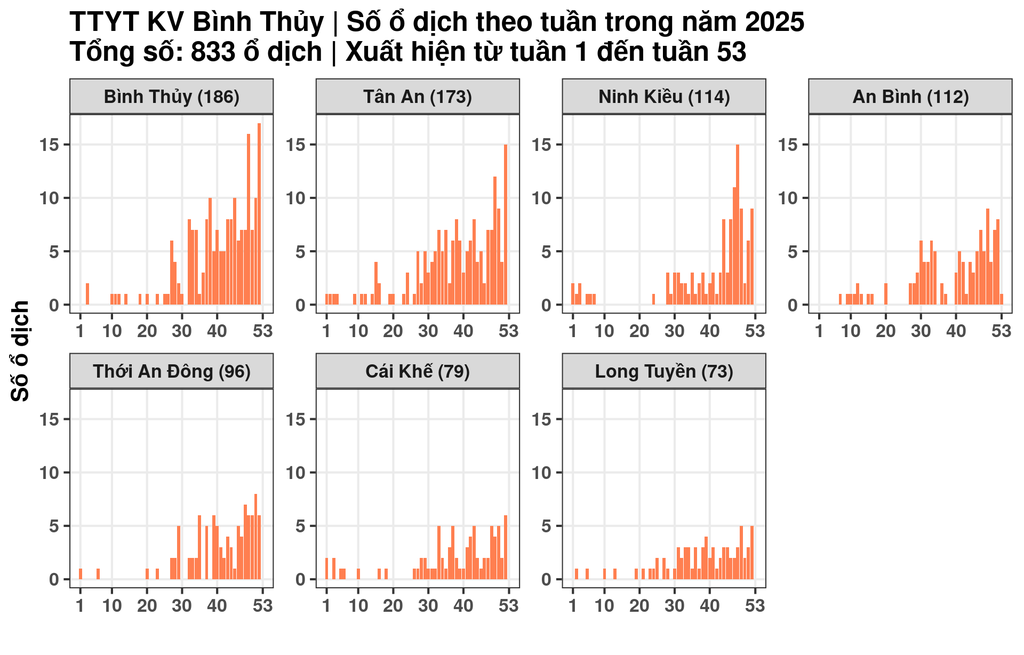

## 9.2 TTYT KV Thới Lai

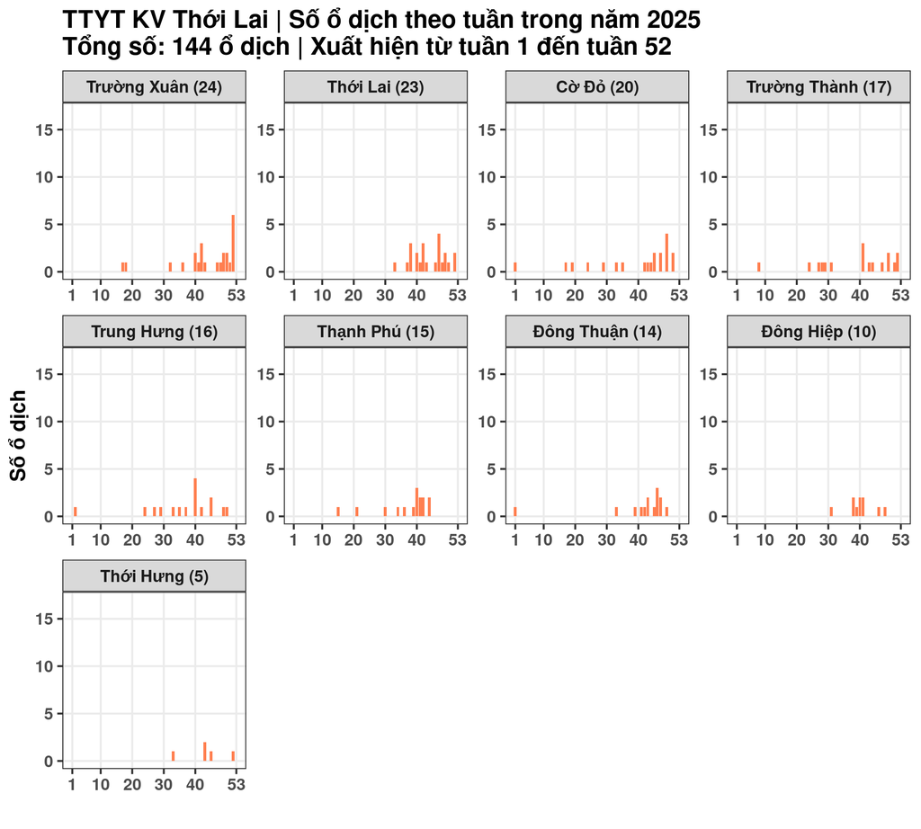

## 9.3 TTYT KV Long Phú

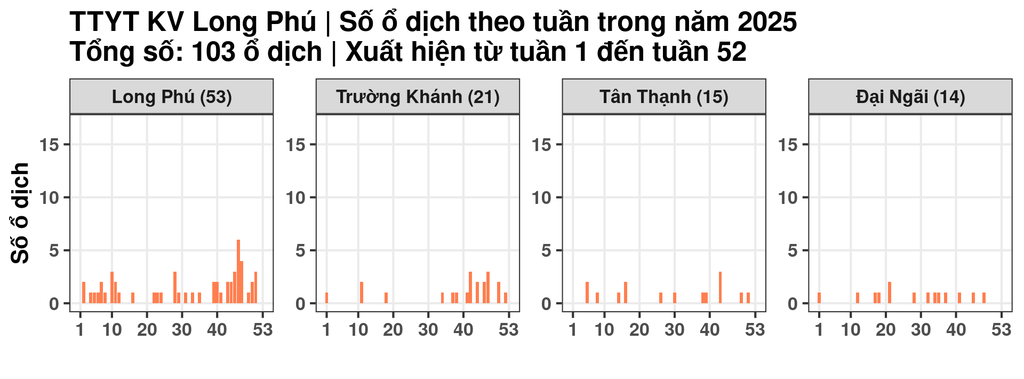

## 9.4 TTYT KV Phụng Hiệp

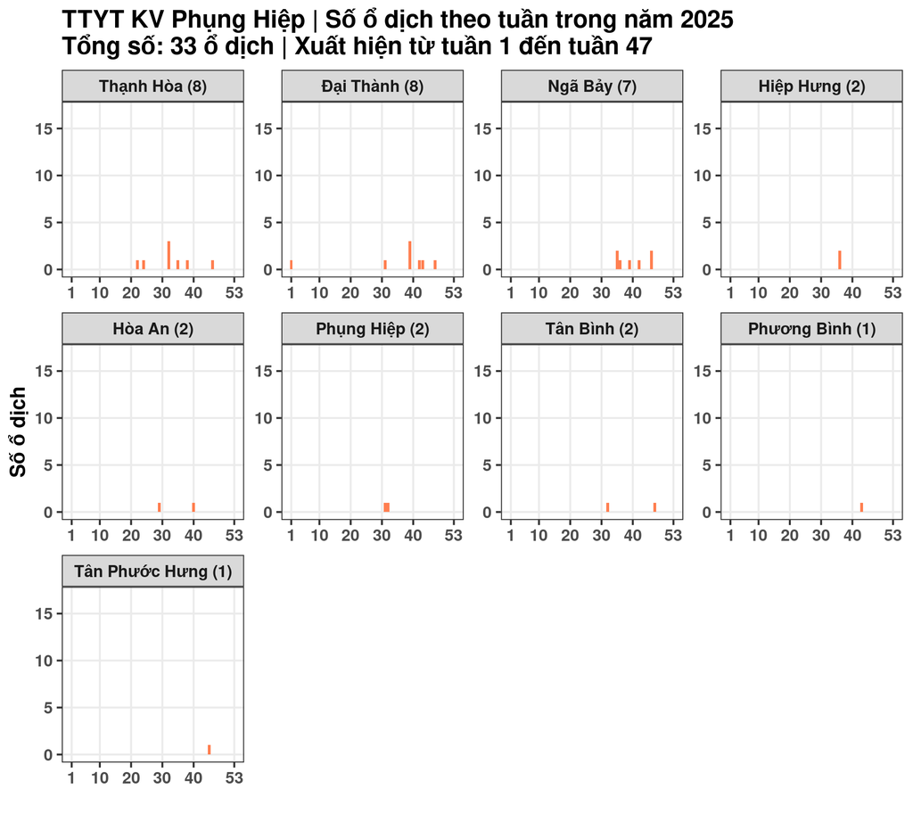

## 9.5 TTYT KV Mỹ Xuyên

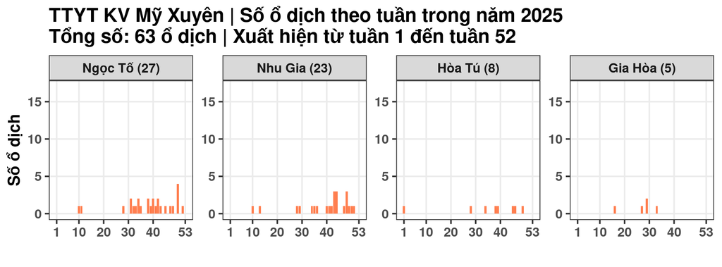